# Supplementary Material

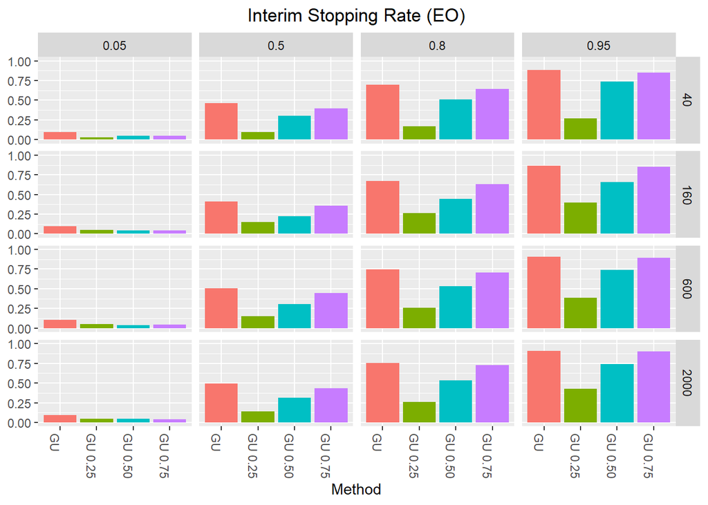

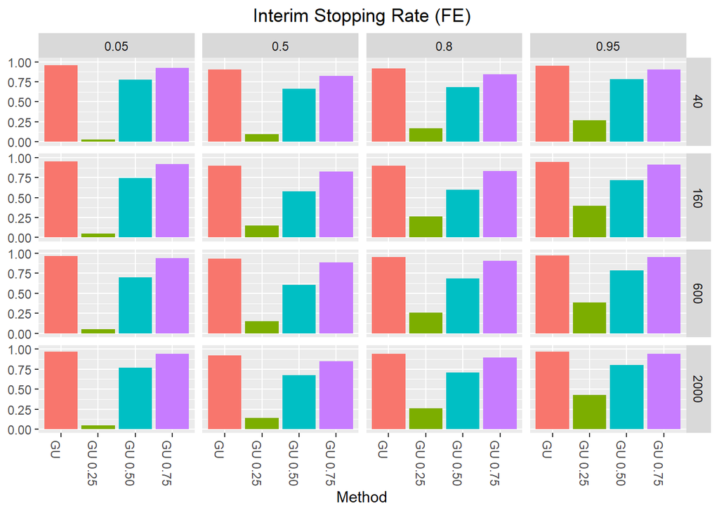

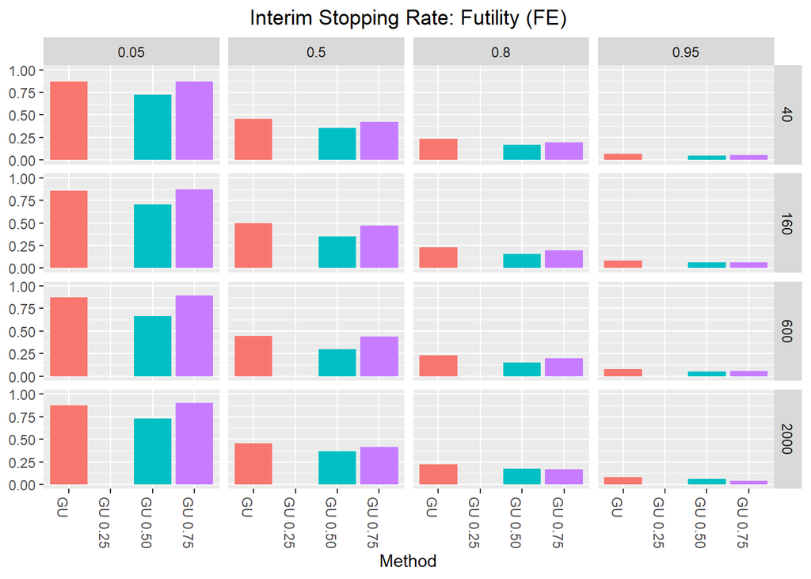

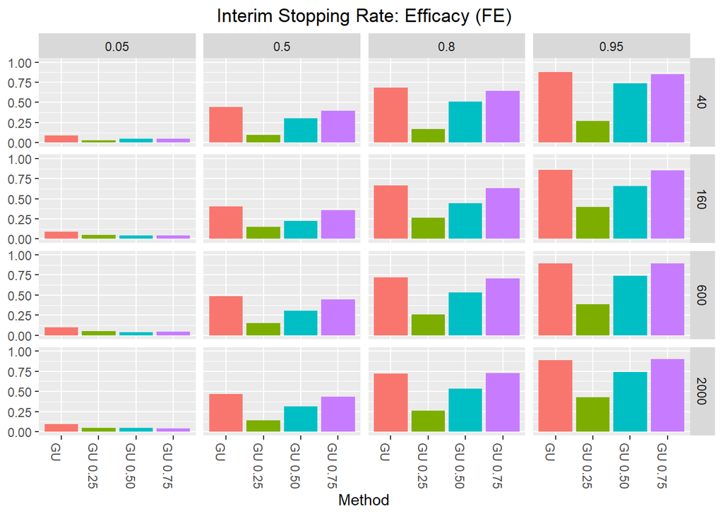

## Combined Data Visualizations

This section includes graphical results summaries comparing simultaneously between all the various versions of upstrapping (CU, AU, or GU) presented in *S1*:*S12*. For each sample size ($N$, shown on the y axis) and power ($\beta$, shown on the x axis) based scenario three evaluation metrics are reported: expected total sample size (*Expected Sample Size*), proportion of trials that either stopped early for efficacy or rejected the null hypothesis with the full sample data (*Rejection Rate*), and proportion of trials that stopped early at any interim stopping point (*Interim Stopping Rate*). Results for futility only monitoring (FO), efficacy only monitoring (EO) and simultaneous futility and efficacy monitoring (FE) are shown separately. The *CU, AU, GU* methods refer to trials designed with sequential stopping points at 25%, 50%, and 75% of the total sample size. The *CU 0.25, AU 0.25, GU 0.25* methods refer to trials designed with a single interim stopping point at 25% of the total sample size. The *CU 0.50, AU 0.50, GU 0.50* methods refer to trials designed with a single interim stopping point at 50% of the total sample size. The *CU 0.75, AU 0.75, GU 0.75* methods refer to trials designed with a single interim stopping point at 75% of the total sample size.

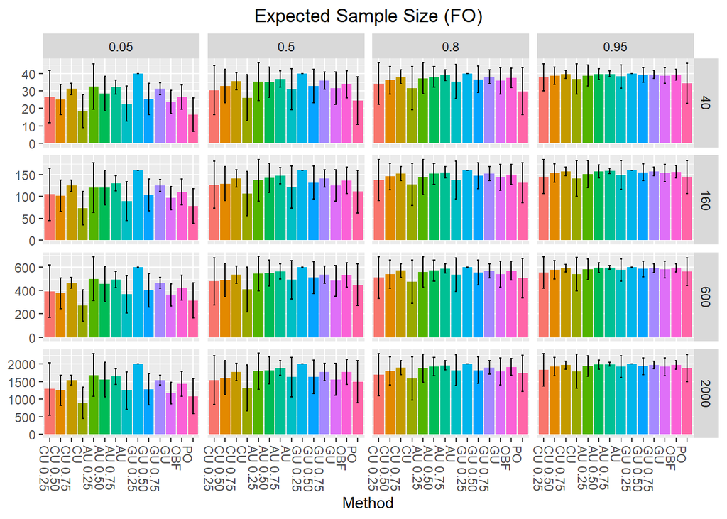

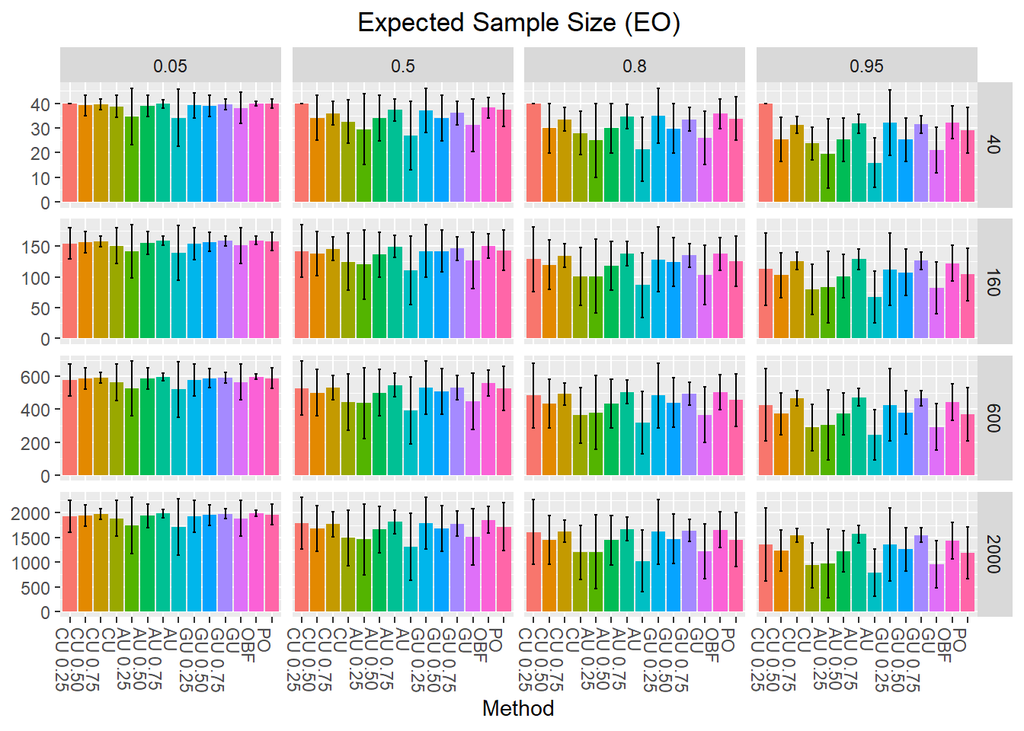

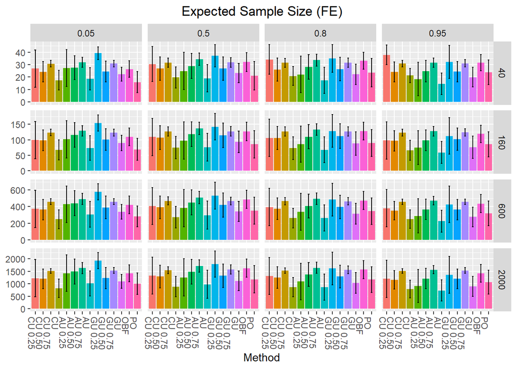

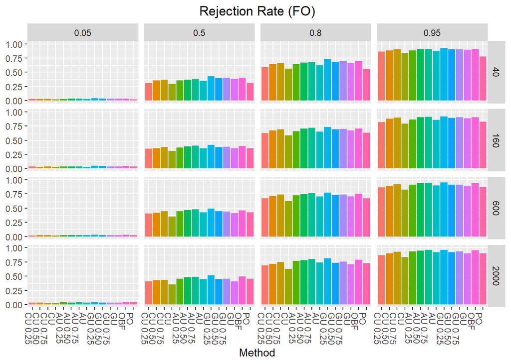

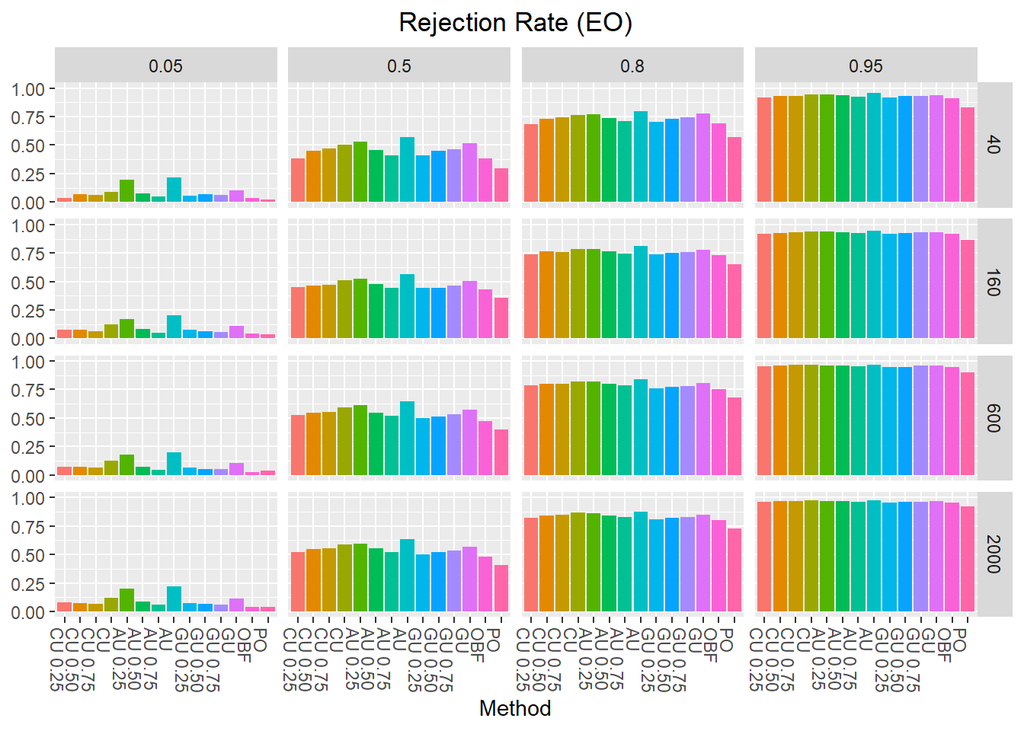

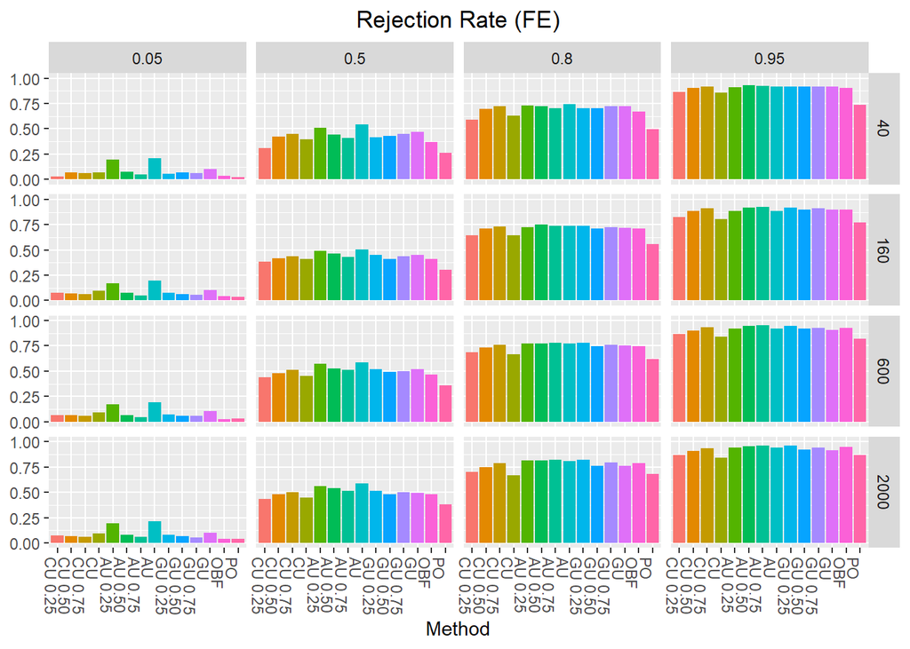

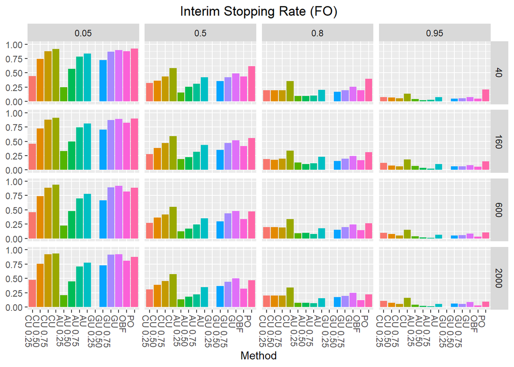

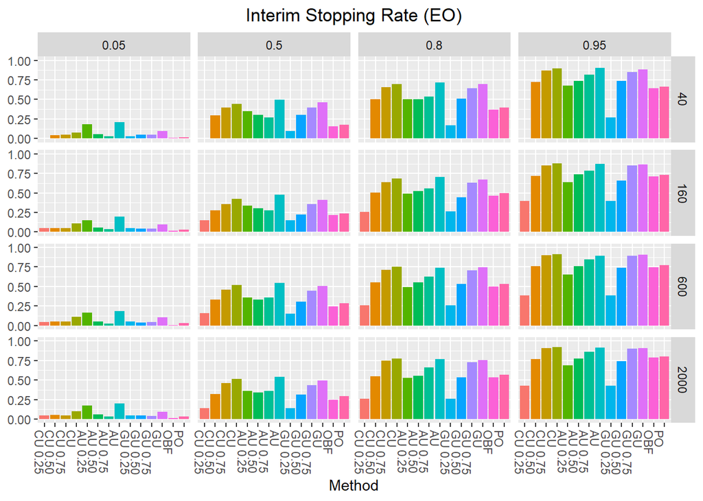

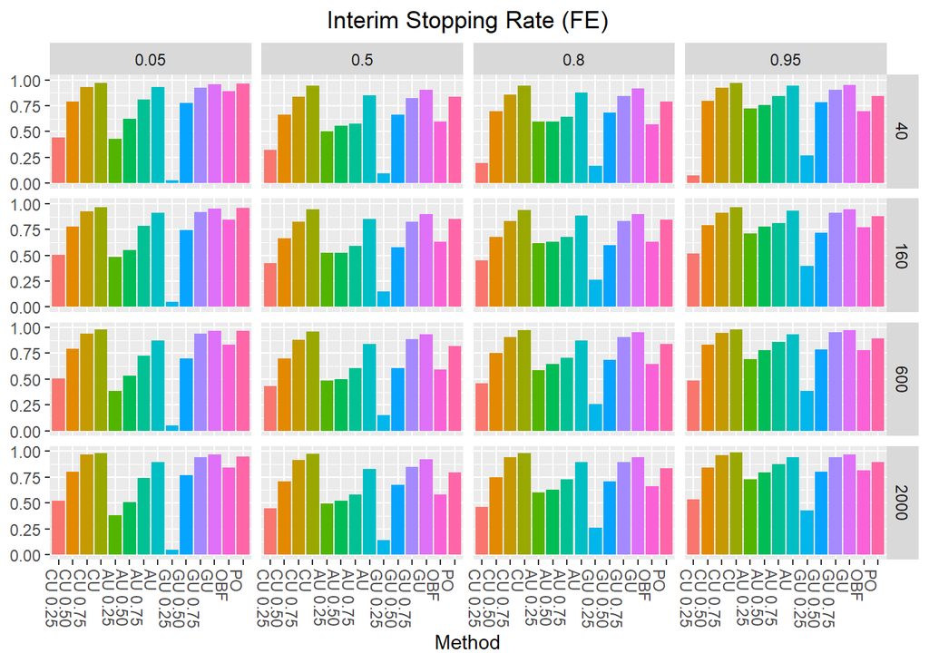

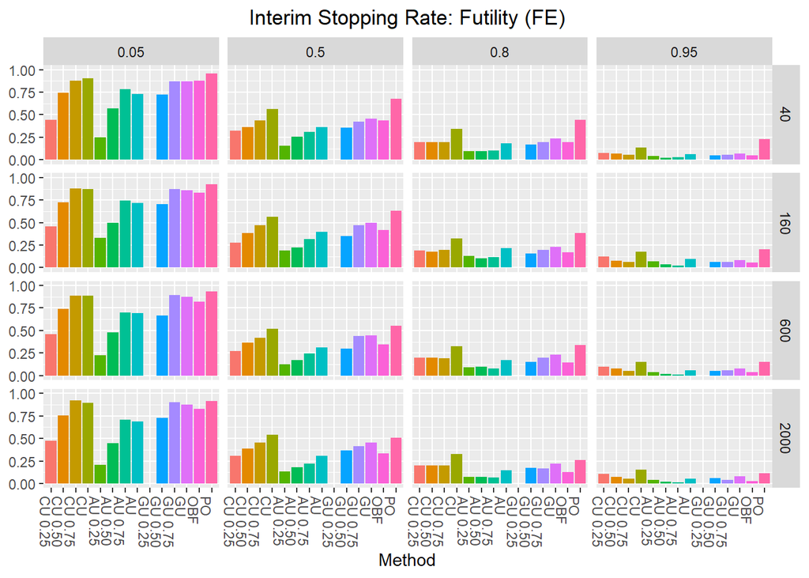

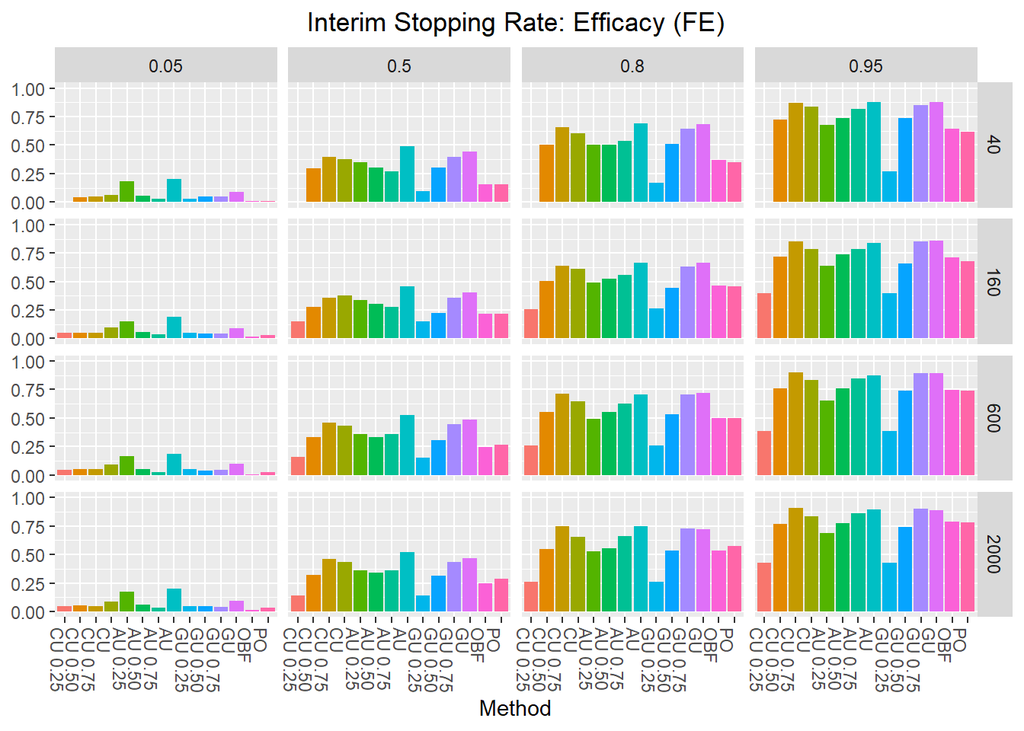